# Exercise 3. Logistic regression

## 1. Reading the dataset ‘alc’

```r
setwd("C:/Users/Sara Allaouat/Documents/IODS-project/data")
alc <- read.table("alc.csv", header = TRUE, sep = "")
str(alc)
```

```
## 'data.frame':    382 obs. of  35 variables:
##  $ school    : Factor w/ 2 levels "GP","MS": 1 1 1 1 1 1 1 1 1 1 ...
##  $ sex       : Factor w/ 2 levels "F","M": 1 1 1 1 1 2 2 1 2 2 ...
##  $ age       : int  18 17 15 15 16 16 16 17 15 15 ...
##  $ address   : Factor w/ 2 levels "R","U": 2 2 2 2 2 2 2 2 2 2 ...
##  $ famsize   : Factor w/ 2 levels "GT3","LE3": 1 1 2 1 1 2 2 1 2 1 ...
##  $ Pstatus   : Factor w/ 2 levels "A","T": 1 2 2 2 2 2 2 1 1 2 ...
##  $ Medu      : int  4 1 1 4 3 4 2 4 3 3 ...
##  $ Fedu      : int  4 1 1 2 3 3 2 4 2 4 ...
##  $ Mjob      : Factor w/ 5 levels "at_home","health",..: 1 1 1 2 3 4 3 3 4 3 ...
##  $ Fjob      : Factor w/ 5 levels "at_home","health",..: 5 3 3 4 3 3 3 5 3 3 ...
##  $ reason    : Factor w/ 4 levels "course","home",..: 1 1 3 2 2 4 2 2 2 2 ...
##  $ nursery   : Factor w/ 2 levels "no","yes": 2 1 2 2 2 2 2 2 2 2 ...
##  $ internet  : Factor w/ 2 levels "no","yes": 1 2 2 2 1 2 2 1 2 2 ...
##  $ guardian  : Factor w/ 3 levels "father","mother",..: 2 1 2 2 1 2 2 2 2 2 ...
```

[output cut: 21 more lines]

```r
colnames(alc)
```

```
##  [1] "school"     "sex"        "age"        "address"    "famsize"
##  [6] "Pstatus"    "Medu"       "Fedu"       "Mjob"       "Fjob"
## [11] "reason"     "nursery"    "internet"   "guardian"   "traveltime"
## [16] "studytime"  "failures"   "schoolsup"  "famsup"     "paid"
## [21] "activities" "higher"     "romantic"   "famrel"     "freetime"
## [26] "goout"      "Dalc"       "Walc"       "health"     "absences"
## [31] "G1"         "G2"         "G3"         "alc_use"    "high_use"
```

The dataset ‘alc’ has 382 observations of 35 variables, including 16 integer variables, 17 factor variables, one numeric variable ‘alc_use’ and one logical variable ‘high_use’. These two last variables are related to alcohol consumption.  
In these 35 variables, there are 13 student identifiers giving information about age, sex, address, school, family size and situation and parents’ education and job, nursery attendance and internet access at home.  
The other 22 variables describe different aspects related to studying, school and education, alcohol consumption, free time and social life, health status, family and personal situation.

## 2. Hypotheses behind alcohol consumption among students

From the datset, high alcohol consumption could be explained by the following four variables:  
1. Pstatus. Parents living apart ‘A’ is associated with high alcohol consumption.  
2. failures. Increased failure is associated with increased alcohol consumption.  
3. famrel. Decreasing family relationship is associated with increasing alcohol consumption.  
4.absences. Increasing absences are associated with increased alcohol consumption.

## 3. Numerical and graphical exploration of selected variables distributions and their relationship with alcohol consumption

```r
install.packages("tidyr")
install.packages("dplyr")
install.packages("ggplot2")
library(tidyr)
library(dplyr)
library(ggplot2)
```

### Distribution of the chosen variables

```r
glimpse(alc)
gather(alc, key= "key", value = "value", alc_use, Pstatus, failures, famrel, absences) %>% glimpse
gather(alc, key= "key", value = "value", alc_use, Pstatus, failures, famrel, absences) %>% ggplot(aes(value)) + geom_bar() + facet_wrap("key", scales = "free")
hist(alc$absences)
```

[output not shown]

### Numerical exploration

```r
tab <- alc %>% group_by(Pstatus, high_use) %>% summarise(count = n(), mean(failures), mean(famrel), mean(absences))
print(as.data.frame(tab))
```

[output not shown]

### Relationships with alcohol consumption

**Alcohol use by Pstatus**

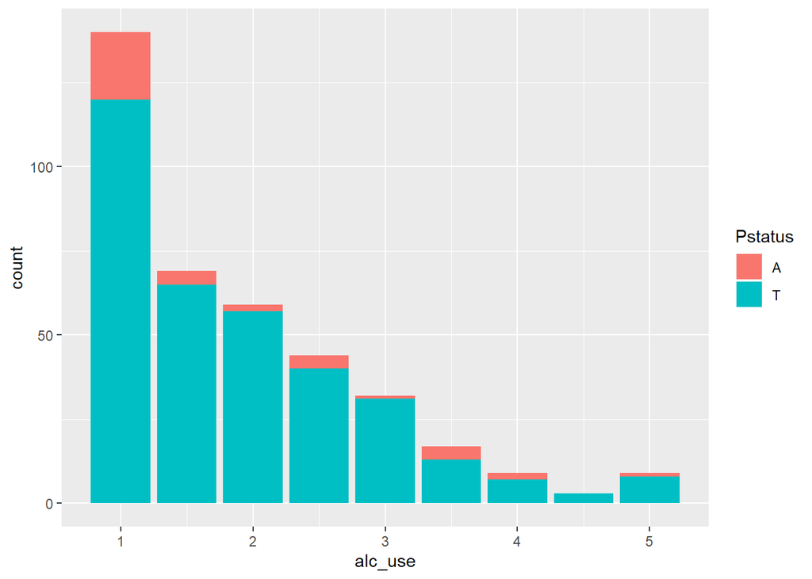

```r
library(ggplot2)
g3 <- ggplot(data = alc, aes(x = alc_use, fill=Pstatus))
g4 <- g3 + geom_bar()
g4
```

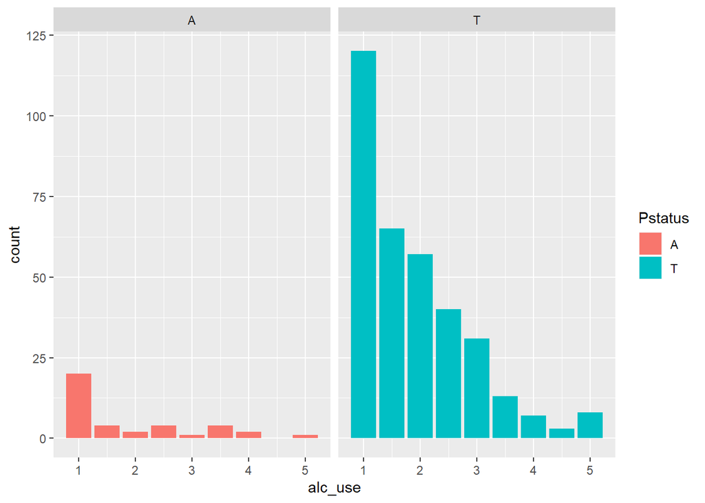

```r
g5 <- g3 + geom_bar()+ facet_wrap("Pstatus")
g5
```

In general, the parental status doesn’t seem to affect the degree of alcohol consumption. In what follows, the parental status won’t be used for comparative analysis because the hypothesis made is based on parents living apart which here represents a very small group which would increase uncertainty of the results.

**Alcohol use by failures**

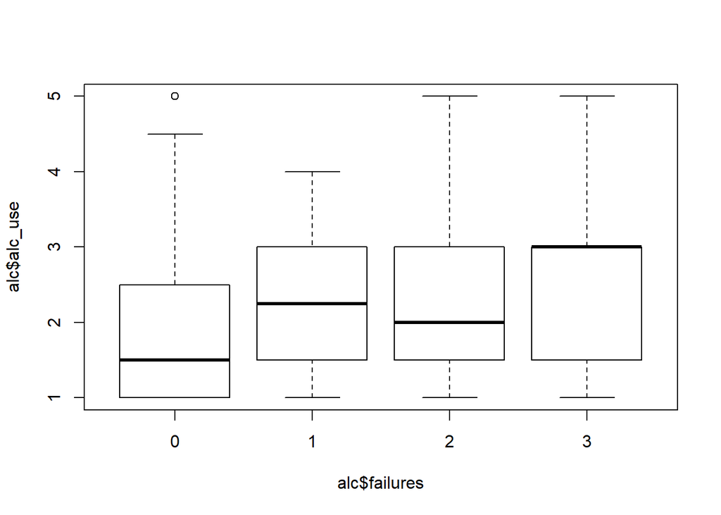

```r
g6 <- boxplot(alc$alc_use ~ alc$failures)
```

```r
g6
```

There is an increasing trend of failures showing an increased alcohol consumption. However, confidence intervals seem large.

**Alcohol use by famrel**

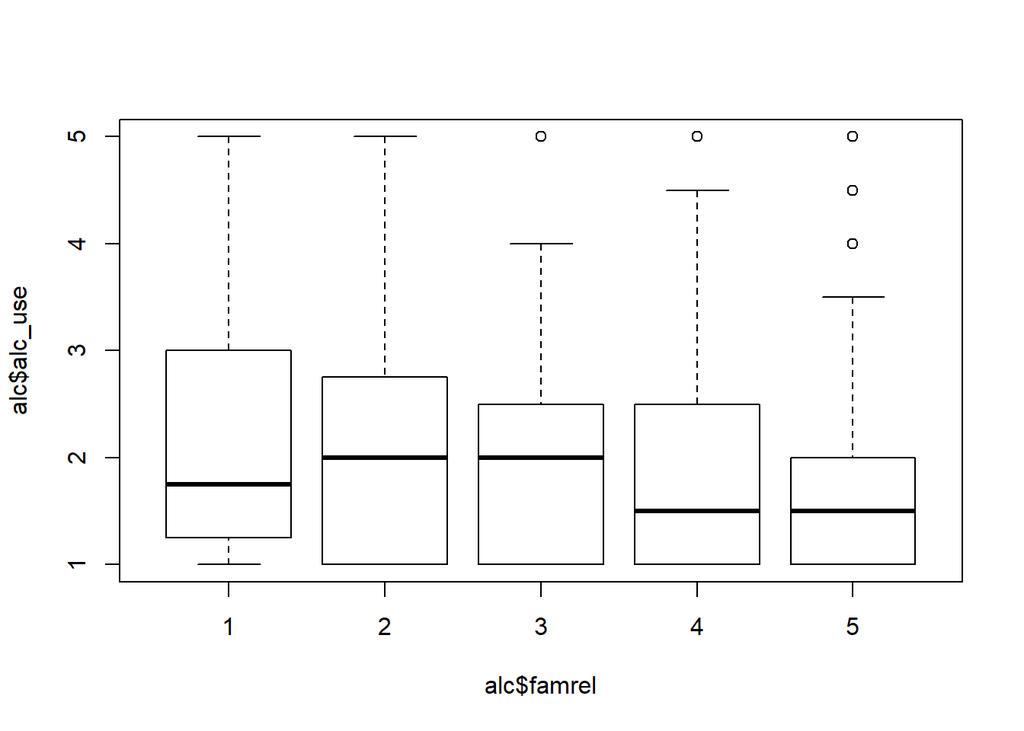

```r
g7 <- boxplot(alc$alc_use ~ alc$famrel)
```

```r
g7
```

Alcohol consumption is the lowest when family relationships are very good or excellent with a narrowed confidence interval for excellent relationships although there are some exceptions (outliers). However, bad family relationships could be associated with high alcohol consumption (large confidence intervals).

**Alcohol use by absences**

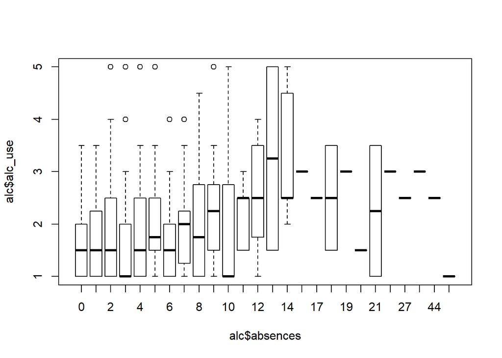

```r
g8 <- boxplot(alc$alc_use ~ alc$absences)
```

```r
g8
```

Alcohol consumption seems to increase with the number of absences and pic around 11-14 absences then decrease. There could be an association between high use of alcohol around these values of absences. More absences could be associated with something else.

## 4. Logistic regression analysis

### Fitted model

```r
m1 <- glm(high_use ~ failures + absences + famrel + Pstatus, data = alc, family = "binomial")
summary(m1)
```

```
##
## Call:
## glm(formula = high_use ~ failures + absences + famrel + Pstatus,
##     family = "binomial", data = alc)
##
## Deviance Residuals:
##     Min       1Q   Median       3Q      Max
## -2.1835  -0.7831  -0.6956   1.1717   1.8929
##
## Coefficients:
##             Estimate Std. Error z value Pr(>|z|)
## (Intercept) -0.58976    0.61903  -0.953 0.340734
## failures     0.47800    0.18365   2.603 0.009247 **
## absences     0.08430    0.02273   3.709 0.000208 ***
## famrel      -0.22917    0.12530  -1.829 0.067394 .
## PstatusT     0.12653    0.39344   0.322 0.747757
## ---
## Signif. codes:  0 '***' 0.001 '**' 0.01 '*' 0.05 '.' 0.1 ' ' 1
##
## (Dispersion parameter for binomial family taken to be 1)
##
##     Null deviance: 465.68  on 381  degrees of freedom
## Residual deviance: 436.75  on 377  degrees of freedom
## AIC: 446.75
##
## Number of Fisher Scoring iterations: 4
```

Both failures and absences have positive and statistically significant estimates (Pr < 0.05). They both increase the probability of high alcohol use.

```r
m2 <- glm(high_use ~ failures + absences, data = alc, family = "binomial")
summary(m2)
```

```
##
## Call:
## glm(formula = high_use ~ failures + absences, family = "binomial",
##     data = alc)
##
## Deviance Residuals:
##     Min       1Q   Median       3Q      Max
## -2.2680  -0.8019  -0.6967   1.2522   1.7906
##
## Coefficients:
##             Estimate Std. Error z value Pr(>|z|)
## (Intercept) -1.37829    0.16479  -8.364  < 2e-16 ***
## failures     0.49972    0.18456   2.708 0.006776 **
## absences     0.08602    0.02287   3.762 0.000169 ***
## ---
## Signif. codes:  0 '***' 0.001 '**' 0.01 '*' 0.05 '.' 0.1 ' ' 1
##
## (Dispersion parameter for binomial family taken to be 1)
##
##     Null deviance: 465.68  on 381  degrees of freedom
## Residual deviance: 440.14  on 379  degrees of freedom
## AIC: 446.14
##
## Number of Fisher Scoring iterations: 4
```

After removing noise from the model (Pstatus and famrel), failures and absences still explain high alcohol use (Pr < 0.05).

### Odds ratios and their respective confidence intervals

```r
OR <- coef(m2) %>% exp
CI <- confint(m2)%>% exp
cbind(OR, CI)
```

```
##                   OR     2.5 %    97.5 %
## (Intercept) 0.252010 0.1806814 0.3450734
## failures    1.648255 1.1488991 2.3830880
## absences    1.089826 1.0443334 1.1423489
```

If failures increase by 1, there is 1.65 time risk of high alcohol use. If absences increase by 1, there is 1.09 time risk of high alcohol use. The lower bounds of confidence intervals are higher then 1 for both failures and absences, which means that the results are statistically significant.

**Comparison with stated hypotheses**  
**1. Pstatus.** Parents living apart ‘A’ is not associated with high alcohol consumption.  
**2. failures.** Increased failure is associated with increased alcohol consumption.  
**3. famrel.** Decreasing family relationship is not associated with increasing alcohol consumption.  
**4. absences.** Increasing absences are associated with increased alcohol consumption.

## 5. Predictions

```r
probabilities <- predict(m2, type = "response")
alc <- mutate(alc, probability = probabilities)
alc <- mutate(alc, prediction = probability > 0.5)
select(alc, failures, absences, high_use, probability, prediction) %>% tail(10)
```

```
##     failures absences high_use probability prediction
## 373        1        0    FALSE   0.2934743      FALSE
## 374        1        7     TRUE   0.4313255      FALSE
## 375        0        1    FALSE   0.2154691      FALSE
## 376        0        6    FALSE   0.2968841      FALSE
## 377        1        2    FALSE   0.3303652      FALSE
## 378        0        2    FALSE   0.2303651      FALSE
## 379        2        2    FALSE   0.4484793      FALSE
## 380        0        3    FALSE   0.2459680      FALSE
## 381        0        4     TRUE   0.2622677      FALSE
## 382        0        2     TRUE   0.2303651      FALSE
```

```r
table(high_use = alc$high_use, prediction = alc$prediction)
```

```
##         prediction
## high_use FALSE TRUE
##    FALSE   258   10
##    TRUE     99   15
```

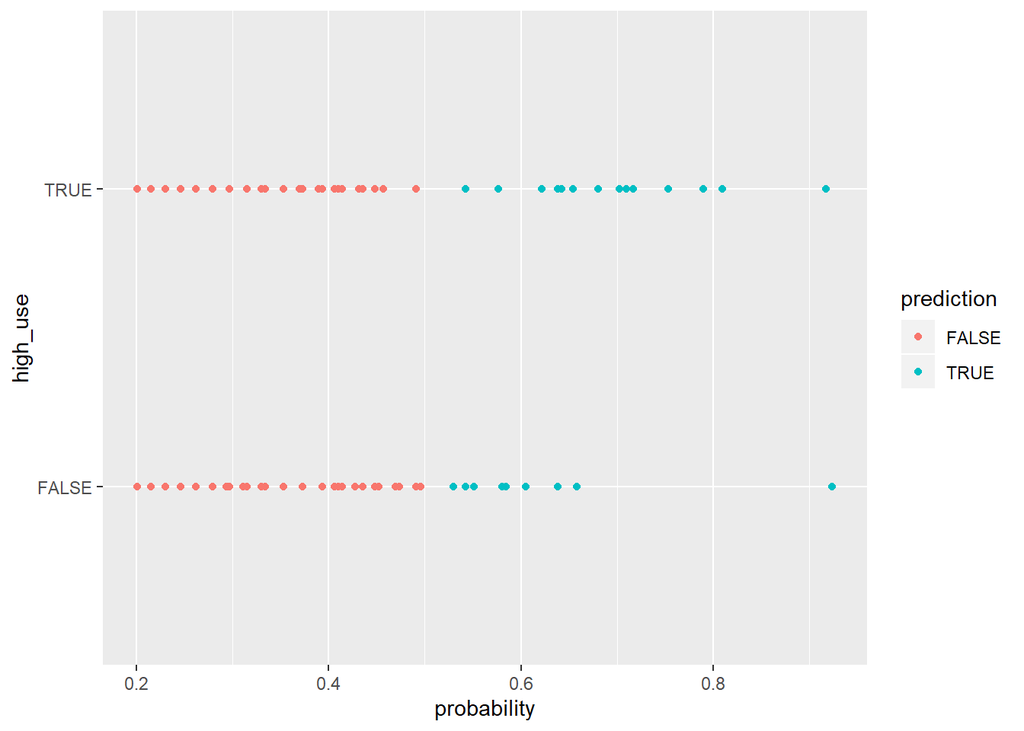

```r
g <- ggplot(alc, aes(x = probability, y = high_use, col=prediction))
g + geom_point()
```

```r
table(high_use = alc$high_use, prediction = alc$prediction) %>% prop.table() %>% addmargins()
```

```
##         prediction
## high_use      FALSE       TRUE        Sum
##    FALSE 0.67539267 0.02617801 0.70157068
##    TRUE  0.25916230 0.03926702 0.29842932
##    Sum   0.93455497 0.06544503 1.00000000
```

From the plots, we can see that true negative and true positive observations are larger in number than false predictions.  
In terms of probability, there are 71.47% (0.67539267+0.03926702) chances to make a true estimate with the model m2.

```r
loss_func <- function(class, prob) {
  n_wrong <- abs(class - prob) > 0.5
  mean(n_wrong)
}
loss_func(class = alc$high_use, prob = alc$probability)
```

```
## [1] 0.2853403
```

The average number of wrong predictions in the dataset is 0.2853403. It means that 28,5% of the observations are incorrectly classified.

## 6. Cross-validation of the model

```r
library(boot)
cv <- cv.glm(data = alc, cost = loss_func, glmfit = m2, K = 10)
cv$delta[1]
```

```
## [1] 0.2931937
```

The average number of wrong predictions in the cross validation is 0.2931937. It means that 29,3% of the observations are incorrectly classified. It is larger than the 0.26 error found in the datacamp example. This means that my model(m2) is not as good as the datacamp model(m). The main difference is the variable sex, which is missing from my model and which also should be associated with high alcohol use.

## 7. Cross-validation of multiple models

```r
M <- glm(high_use ~ failures + absences + sex + Pstatus + famrel + age + school + address + famsize + Medu + Fedu + Mjob + Fjob + reason + guardian + traveltime + studytime + schoolsup + famsup + paid + activities + nursery + higher + internet + romantic + freetime + goout + health, data = alc, family = "binomial")
summary(M)
```

```
##
## Call:
## glm(formula = high_use ~ failures + absences + sex + Pstatus +
##     famrel + age + school + address + famsize + Medu + Fedu +
##     Mjob + Fjob + reason + guardian + traveltime + studytime +
##     schoolsup + famsup + paid + activities + nursery + higher +
##     internet + romantic + freetime + goout + health, family = "binomial",
##     data = alc)
##
## Deviance Residuals:
##     Min       1Q   Median       3Q      Max
## -1.8291  -0.6844  -0.3639   0.5068   2.8280
##
## Coefficients:
##                    Estimate Std. Error z value Pr(>|z|)
## (Intercept)      -4.6992632  3.0352971  -1.548 0.121573
## failures          0.1905745  0.2593303   0.735 0.462418
## absences          0.0890958  0.0265363   3.358 0.000786 ***
## sexM              0.7746132  0.3265569   2.372 0.017689 *
## PstatusT         -0.3869453  0.5355652  -0.722 0.469988
## famrel           -0.5601515  0.1662293  -3.370 0.000752 ***
## age               0.1097373  0.1485166   0.739 0.459974
## schoolMS         -0.6652109  0.5427767  -1.226 0.220361
## addressU         -0.7756170  0.4119713  -1.883 0.059742 .
## famsizeLE3        0.5234672  0.3233113   1.619 0.105430
## Medu              0.0399913  0.2207115   0.181 0.856216
## Fedu              0.1836983  0.1960399   0.937 0.348735
## Mjobhealth       -1.0081463  0.7539923  -1.337 0.181197
## Mjobother        -0.8801032  0.4977692  -1.768 0.077045 .
## Mjobservices     -0.8228564  0.5656394  -1.455 0.145742
## Mjobteacher      -0.2718917  0.6912361  -0.393 0.694067
## Fjobhealth        0.3477598  1.1905465   0.292 0.770209
## Fjobother         0.8013426  0.8598239   0.932 0.351344
## Fjobservices      1.3652232  0.8783334   1.554 0.120105
## Fjobteacher      -0.4356830  1.0290221  -0.423 0.672007
## reasonhome        0.4629453  0.3804955   1.217 0.223722
## reasonother       1.4718642  0.5397528   2.727 0.006393 **
## reasonreputation -0.0760900  0.4103136  -0.185 0.852881
## guardianmother   -0.7911082  0.3653535  -2.165 0.030363 *
## guardianother    -0.2066399  0.7893904  -0.262 0.793498
```

[output cut: 8 more lines]

```
## internetyes       0.0704843  0.4555119   0.155 0.877029
## romanticyes      -0.5512853  0.3304254  -1.668 0.095234 .
## freetime          0.3052430  0.1673445   1.824 0.068146 .
## goout             0.8495939  0.1500830   5.661 1.51e-08 ***
## health            0.1793237  0.1127684   1.590 0.111791
## ---
## Signif. codes:  0 '***' 0.001 '**' 0.01 '*' 0.05 '.' 0.1 ' ' 1
##
## (Dispersion parameter for binomial family taken to be 1)
##
##     Null deviance: 465.68  on 381  degrees of freedom
## Residual deviance: 322.49  on 344  degrees of freedom
## AIC: 398.49
##
## Number of Fisher Scoring iterations: 5
```

```r
probabilities <- predict(M, type = "response")
alc <- mutate(alc, probability = probabilities)
alc <- mutate(alc, prediction = probability > 0.5)
select(alc, failures, absences, sex, Pstatus, famrel, age, school, address, famsize, Medu, Fedu, Mjob, Fjob, reason, guardian,  traveltime, studytime, schoolsup, famsup, paid, activities, nursery, higher, internet, romantic, freetime, goout, health, high_use, probability, prediction) %>% tail(10)
```

```
##     failures absences sex Pstatus famrel age school address famsize Medu
## 373        1        0   M       T      4  19     MS       R     GT3    1
## 374        1        7   M       T      5  18     MS       R     GT3    4
## 375        0        1   F       T      5  18     MS       R     GT3    2
## 376        0        6   F       T      4  18     MS       R     GT3    4
## 377        1        2   F       T      5  19     MS       R     GT3    2
## 378        0        2   F       T      4  18     MS       U     LE3    3
## 379        2        2   F       T      2  18     MS       U     GT3    1
## 380        0        3   F       T      1  18     MS       U     GT3    1
## 381        0        4   M       T      2  17     MS       U     LE3    3
## 382        0        2   M       T      4  18     MS       R     LE3    3
##     Fedu     Mjob     Fjob     reason guardian traveltime studytime
## 373    1    other services      other   mother          2         1
## 374    2    other    other       home   father          2         1
## 375    2  at_home    other      other   mother          2         3
```

[output cut: 29 more lines]

```r
table(high_use = alc$high_use, prediction = alc$prediction)
```

```
##         prediction
## high_use FALSE TRUE
##    FALSE   246   22
##    TRUE     51   63
```

```r
loss_func1 <- function(class, prob) {
  n_wrong <- abs(class - prob) > 0.5
  mean(n_wrong)
}
loss_func1(class = alc$high_use, prob = alc$probability)
```

```
## [1] 0.1910995
```

```r
cv1 <- cv.glm(data = alc, cost = loss_func1, glmfit = M, K = 10)
cv1$delta[1]
```

```
## [1] 0.2460733
```

```r
M2 <- glm(high_use ~ failures + absences + sex + famrel + age + address + famsize + Fedu + Fjob + guardian + traveltime + studytime + paid + activities + nursery + romantic + freetime + goout + health, data = alc, family = "binomial")
summary(M2)
```

```
##
## Call:
## glm(formula = high_use ~ failures + absences + sex + famrel +
##     age + address + famsize + Fedu + Fjob + guardian + traveltime +
##     studytime + paid + activities + nursery + romantic + freetime +
##     goout + health, family = "binomial", data = alc)
##
## Deviance Residuals:
##     Min       1Q   Median       3Q      Max
## -1.7906  -0.7016  -0.3843   0.5491   2.7042
##
## Coefficients:
##                Estimate Std. Error z value Pr(>|z|)
## (Intercept)    -4.22679    2.56068  -1.651 0.098810 .
## failures        0.23352    0.24995   0.934 0.350172
## absences        0.08713    0.02347   3.712 0.000206 ***
## sexM            0.82819    0.30232   2.739 0.006155 **
## famrel         -0.49038    0.15966  -3.071 0.002131 **
## age             0.05539    0.12867   0.430 0.666873
## addressU       -0.71109    0.36222  -1.963 0.049632 *
## famsizeLE3      0.43877    0.30934   1.418 0.156068
## Fedu            0.20512    0.15366   1.335 0.181921
## Fjobhealth      0.37097    1.09753   0.338 0.735359
## Fjobother       0.54468    0.84214   0.647 0.517774
## Fjobservices    1.17579    0.85726   1.372 0.170198
## Fjobteacher    -0.27903    0.99086  -0.282 0.778246
## guardianmother -0.52751    0.33498  -1.575 0.115311
## guardianother   0.07124    0.75024   0.095 0.924352
## traveltime      0.24782    0.21828   1.135 0.256238
## studytime      -0.34264    0.18998  -1.804 0.071295 .
## paidyes         0.69081    0.28984   2.383 0.017152 *
## activitiesyes  -0.53354    0.28791  -1.853 0.063864 .
## nurseryyes     -0.43818    0.34787  -1.260 0.207816
## romanticyes    -0.42484    0.31239  -1.360 0.173836
## freetime        0.21986    0.15553   1.414 0.157481
## goout           0.77448    0.14039   5.517 3.45e-08 ***
## health          0.15067    0.10418   1.446 0.148100
## ---
## Signif. codes:  0 '***' 0.001 '**' 0.01 '*' 0.05 '.' 0.1 ' ' 1
##
## (Dispersion parameter for binomial family taken to be 1)
##
##     Null deviance: 465.68  on 381  degrees of freedom
## Residual deviance: 336.58  on 358  degrees of freedom
## AIC: 384.58
##
## Number of Fisher Scoring iterations: 5
```

```r
probabilities <- predict(M2, type = "response")
alc <- mutate(alc, probability = probabilities)
alc <- mutate(alc, prediction = probability > 0.5)
select(alc, failures, absences, sex, famrel, age, school, address, famsize, Fedu, Fjob, guardian,  traveltime, studytime, paid, activities, nursery, romantic, freetime, goout, health, high_use, probability, prediction) %>% tail(10)
```

```
##     failures absences sex famrel age school address famsize Fedu     Fjob
## 373        1        0   M      4  19     MS       R     GT3    1 services
## 374        1        7   M      5  18     MS       R     GT3    2    other
## 375        0        1   F      5  18     MS       R     GT3    2    other
## 376        0        6   F      4  18     MS       R     GT3    4  at_home
## 377        1        2   F      5  19     MS       R     GT3    3    other
## 378        0        2   F      4  18     MS       U     LE3    1 services
## 379        2        2   F      2  18     MS       U     GT3    1    other
## 380        0        3   F      1  18     MS       U     GT3    1    other
## 381        0        4   M      2  17     MS       U     LE3    1 services
## 382        0        2   M      4  18     MS       R     LE3    2    other
##     guardian traveltime studytime paid activities nursery romantic
## 373   mother          2         1   no         no     yes       no
## 374   father          2         1  yes         no     yes       no
## 375   mother          2         3  yes         no     yes       no
```

[output cut: 18 more lines]

```r
table(high_use = alc$high_use, prediction = alc$prediction)
```

```
##         prediction
## high_use FALSE TRUE
##    FALSE   243   25
##    TRUE     54   60
```

```r
loss_func2 <- function(class, prob) {
  n_wrong <- abs(class - prob) > 0.5
  mean(n_wrong)
}
loss_func2(class = alc$high_use, prob = alc$probability)
```

```
## [1] 0.2068063
```

```r
cv2 <- cv.glm(data = alc, cost = loss_func2, glmfit = M2, K = 10)
cv2$delta[1]
```

```
## [1] 0.2382199
```

```r
M3 <- glm(high_use ~ failures + absences + sex + famrel + address + famsize + guardian + traveltime + studytime + paid + activities + nursery + romantic + freetime + goout + health, data = alc, family = "binomial")
summary(M3)
```

```
##
## Call:
## glm(formula = high_use ~ failures + absences + sex + famrel +
##     address + famsize + guardian + traveltime + studytime + paid +
##     activities + nursery + romantic + freetime + goout + health,
##     family = "binomial", data = alc)
##
## Deviance Residuals:
##     Min       1Q   Median       3Q      Max
## -1.8235  -0.7049  -0.4153   0.5961   2.7203
##
## Coefficients:
##                Estimate Std. Error z value Pr(>|z|)
## (Intercept)    -2.05346    1.05602  -1.945  0.05183 .
## failures        0.20623    0.22846   0.903  0.36670
## absences        0.09047    0.02294   3.943 8.05e-05 ***
## sexM            0.84962    0.29719   2.859  0.00425 **
## famrel         -0.43874    0.15644  -2.805  0.00504 **
## addressU       -0.78720    0.35474  -2.219  0.02648 *
## famsizeLE3      0.41918    0.30038   1.396  0.16286
## guardianmother -0.68786    0.32219  -2.135  0.03276 *
## guardianother   0.08881    0.71036   0.125  0.90050
## traveltime      0.18308    0.21053   0.870  0.38451
## studytime      -0.34290    0.18667  -1.837  0.06622 .
## paidyes         0.77273    0.28475   2.714  0.00665 **
## activitiesyes  -0.44542    0.27834  -1.600  0.10954
## nurseryyes     -0.37863    0.33401  -1.134  0.25696
## romanticyes    -0.40804    0.29931  -1.363  0.17280
## freetime        0.14029    0.14880   0.943  0.34577
## goout           0.81078    0.13740   5.901 3.62e-09 ***
## health          0.14338    0.10093   1.421  0.15544
## ---
## Signif. codes:  0 '***' 0.001 '**' 0.01 '*' 0.05 '.' 0.1 ' ' 1
##
## (Dispersion parameter for binomial family taken to be 1)
##
##     Null deviance: 465.68  on 381  degrees of freedom
## Residual deviance: 345.89  on 364  degrees of freedom
## AIC: 381.89
##
## Number of Fisher Scoring iterations: 5
```

```r
probabilities <- predict(M3, type = "response")
alc <- mutate(alc, probability = probabilities)
alc <- mutate(alc, prediction = probability > 0.5)
select(alc, failures, absences, sex, famrel, school, address, famsize, guardian,  traveltime, studytime, paid, activities, nursery, romantic, freetime, goout, health, high_use, probability, prediction) %>% tail(10)
```

```
##     failures absences sex famrel school address famsize guardian
## 373        1        0   M      4     MS       R     GT3   mother
## 374        1        7   M      5     MS       R     GT3   father
## 375        0        1   F      5     MS       R     GT3   mother
## 376        0        6   F      4     MS       R     GT3   mother
## 377        1        2   F      5     MS       R     GT3   mother
## 378        0        2   F      4     MS       U     LE3   mother
## 379        2        2   F      2     MS       U     GT3   mother
## 380        0        3   F      1     MS       U     GT3   mother
## 381        0        4   M      2     MS       U     LE3   mother
## 382        0        2   M      4     MS       R     LE3   mother
##     traveltime studytime paid activities nursery romantic freetime goout
## 373          2         1   no         no     yes       no        3     2
## 374          2         1  yes         no     yes       no        4     3
## 375          2         3  yes         no     yes       no        3     3
```

[output cut: 18 more lines]

```r
table(high_use = alc$high_use, prediction = alc$prediction)
```

```
##         prediction
## high_use FALSE TRUE
##    FALSE   246   22
##    TRUE     56   58
```

```r
loss_func3 <- function(class, prob) {
  n_wrong <- abs(class - prob) > 0.5
  mean(n_wrong)
}
loss_func3(class = alc$high_use, prob = alc$probability)
```

```
## [1] 0.2041885
```

```r
cv3 <- cv.glm(data = alc, cost = loss_func3, glmfit = M3, K = 10)
cv3$delta[1]
```

```
## [1] 0.2408377
```

```r
M4 <- glm(high_use ~ failures + absences + sex + famrel + address + famsize + traveltime + studytime + paid + activities + nursery + romantic + freetime + goout + health, data = alc, family = "binomial")
summary(M4)
```

```
##
## Call:
## glm(formula = high_use ~ failures + absences + sex + famrel +
##     address + famsize + traveltime + studytime + paid + activities +
##     nursery + romantic + freetime + goout + health, family = "binomial",
##     data = alc)
##
## Deviance Residuals:
##     Min       1Q   Median       3Q      Max
## -1.8693  -0.7237  -0.4254   0.6714   2.7784
##
## Coefficients:
##               Estimate Std. Error z value Pr(>|z|)
## (Intercept)   -2.65297    1.02173  -2.597 0.009417 **
## failures       0.18791    0.22611   0.831 0.405944
## absences       0.08602    0.02281   3.772 0.000162 ***
## sexM           0.86885    0.29364   2.959 0.003087 **
## famrel        -0.43120    0.15345  -2.810 0.004952 **
## addressU      -0.65649    0.34540  -1.901 0.057347 .
## famsizeLE3     0.36152    0.29685   1.218 0.223282
## traveltime     0.24369    0.20398   1.195 0.232214
## studytime     -0.31719    0.18494  -1.715 0.086328 .
## paidyes        0.72499    0.28080   2.582 0.009827 **
## activitiesyes -0.42168    0.27459  -1.536 0.124625
## nurseryyes    -0.44895    0.32963  -1.362 0.173212
## romanticyes   -0.38966    0.29566  -1.318 0.187523
## freetime       0.15436    0.14776   1.045 0.296162
## goout          0.77947    0.13493   5.777 7.62e-09 ***
## health         0.14238    0.09962   1.429 0.152961
## ---
## Signif. codes:  0 '***' 0.001 '**' 0.01 '*' 0.05 '.' 0.1 ' ' 1
##
## (Dispersion parameter for binomial family taken to be 1)
##
##     Null deviance: 465.68  on 381  degrees of freedom
## Residual deviance: 351.18  on 366  degrees of freedom
## AIC: 383.18
##
## Number of Fisher Scoring iterations: 5
```

```r
probabilities <- predict(M4, type = "response")
alc <- mutate(alc, probability = probabilities)
alc <- mutate(alc, prediction = probability > 0.5)
select(alc, failures, absences, sex, famrel, school, address, famsize, traveltime, studytime, paid, activities, nursery, romantic, freetime, goout, health, high_use, probability, prediction) %>% tail(10)
```

```
##     failures absences sex famrel school address famsize traveltime
## 373        1        0   M      4     MS       R     GT3          2
## 374        1        7   M      5     MS       R     GT3          2
## 375        0        1   F      5     MS       R     GT3          2
## 376        0        6   F      4     MS       R     GT3          3
## 377        1        2   F      5     MS       R     GT3          1
## 378        0        2   F      4     MS       U     LE3          1
## 379        2        2   F      2     MS       U     GT3          2
## 380        0        3   F      1     MS       U     GT3          2
## 381        0        4   M      2     MS       U     LE3          2
## 382        0        2   M      4     MS       R     LE3          3
##     studytime paid activities nursery romantic freetime goout health
## 373         1   no         no     yes       no        3     2      5
## 374         1  yes         no     yes       no        4     3      3
## 375         3  yes         no     yes       no        3     3      4
```

[output cut: 18 more lines]

```r
table(high_use = alc$high_use, prediction = alc$prediction)
```

```
##         prediction
## high_use FALSE TRUE
##    FALSE   245   23
##    TRUE     57   57
```

```r
loss_func4 <- function(class, prob) {
  n_wrong <- abs(class - prob) > 0.5
  mean(n_wrong)
}
loss_func4(class = alc$high_use, prob = alc$probability)
```

```
## [1] 0.2094241
```

```r
cv4 <- cv.glm(data = alc, cost = loss_func4, glmfit = M4, K = 10)
cv4$delta[1]
```

```
## [1] 0.2434555
```

```r
M5 <- glm(high_use ~ absences + sex + famrel + address + famsize + traveltime + studytime + paid + activities + nursery + romantic + freetime + goout + health, data = alc, family = "binomial")
summary(M5)
```

```
##
## Call:
## glm(formula = high_use ~ absences + sex + famrel + address +
##     famsize + traveltime + studytime + paid + activities + nursery +
##     romantic + freetime + goout + health, family = "binomial",
##     data = alc)
##
## Deviance Residuals:
##     Min       1Q   Median       3Q      Max
## -1.8943  -0.7224  -0.4232   0.6737   2.7725
##
## Coefficients:
##               Estimate Std. Error z value Pr(>|z|)
## (Intercept)   -2.62288    1.01762  -2.577 0.009953 **
## absences       0.08706    0.02283   3.813 0.000137 ***
## sexM           0.87881    0.29303   2.999 0.002708 **
## famrel        -0.44219    0.15243  -2.901 0.003722 **
## addressU      -0.65650    0.34485  -1.904 0.056946 .
## famsizeLE3     0.34735    0.29635   1.172 0.241154
## traveltime     0.26232    0.20120   1.304 0.192313
## studytime     -0.34360    0.18228  -1.885 0.059427 .
## paidyes        0.68944    0.27708   2.488 0.012840 *
## activitiesyes -0.43807    0.27348  -1.602 0.109191
## nurseryyes    -0.44115    0.32849  -1.343 0.179281
## romanticyes   -0.38371    0.29469  -1.302 0.192892
## freetime       0.15813    0.14739   1.073 0.283326
## goout          0.79430    0.13421   5.918 3.25e-09 ***
## health         0.15031    0.09880   1.521 0.128152
## ---
## Signif. codes:  0 '***' 0.001 '**' 0.01 '*' 0.05 '.' 0.1 ' ' 1
##
## (Dispersion parameter for binomial family taken to be 1)
##
##     Null deviance: 465.68  on 381  degrees of freedom
## Residual deviance: 351.87  on 367  degrees of freedom
## AIC: 381.87
##
## Number of Fisher Scoring iterations: 5
```

```r
probabilities <- predict(M5, type = "response")
alc <- mutate(alc, probability = probabilities)
alc <- mutate(alc, prediction = probability > 0.5)
select(alc, absences, sex, famrel, school, address, famsize, traveltime, studytime, paid, activities, nursery, romantic, freetime, goout, health, high_use, probability, prediction) %>% tail(10)
```

```
##     absences sex famrel school address famsize traveltime studytime paid
## 373        0   M      4     MS       R     GT3          2         1   no
## 374        7   M      5     MS       R     GT3          2         1  yes
## 375        1   F      5     MS       R     GT3          2         3  yes
## 376        6   F      4     MS       R     GT3          3         1  yes
## 377        2   F      5     MS       R     GT3          1         3   no
## 378        2   F      4     MS       U     LE3          1         2  yes
## 379        2   F      2     MS       U     GT3          2         2   no
## 380        3   F      1     MS       U     GT3          2         2   no
## 381        4   M      2     MS       U     LE3          2         1   no
## 382        2   M      4     MS       R     LE3          3         1   no
##     activities nursery romantic freetime goout health high_use probability
## 373         no     yes       no        3     2      5    FALSE  0.27720628
## 374         no     yes       no        4     3      3     TRUE  0.63416210
## 375         no     yes       no        3     3      4    FALSE  0.17565550
```

[output cut: 18 more lines]

```r
table(high_use = alc$high_use, prediction = alc$prediction)
```

```
##         prediction
## high_use FALSE TRUE
##    FALSE   244   24
##    TRUE     57   57
```

```r
loss_func5 <- function(class, prob) {
  n_wrong <- abs(class - prob) > 0.5
  mean(n_wrong)
}
loss_func5(class = alc$high_use, prob = alc$probability)
```

```
## [1] 0.2120419
```

```r
cv5 <- cv.glm(data = alc, cost = loss_func5, glmfit = M5, K = 10)
cv5$delta[1]
```

```
## [1] 0.2251309
```